# Europe's AI Adoption Gap

### Who is pulling ahead, where smaller firms fall behind, and what stops businesses from adopting AI?

**Final Individual Project — Data Visualization, Summer 2026**  
**Student:** Usaid Aamer  
**Data source:** Eurostat enterprise ICT survey (`isoc_eb_ai`, `isoc_eb_ain2`)

This notebook tells one story through twelve analytical questions. It begins with the pace of AI adoption, then examines the divides by country, firm size, and sector, before looking at technology depth, business use cases, and the reasons many firms still do not adopt AI.

## Executive summary

- EU enterprise AI adoption rose from **8.1% in 2023 to 20.0% in 2025**.
- The acceleration was uneven: **Denmark reached 42.0%**, while **Romania remained at 5.2%**.
- Firm size is the most consistent divide. In 2025, **55.0% of large firms** used AI versus **17.0% of small firms**.
- Adoption is also shallow for many businesses: only **8.3% of all EU firms** used at least three AI technologies.
- Among firms that considered AI but did not adopt it, **70.3% cited a lack of expertise**. Skills were a larger barrier than cost.

## Data and analytical scope

The data comes from two official Eurostat tables:

1. [`isoc_eb_ai`](https://ec.europa.eu/eurostat/databrowser/view/isoc_eb_ai/default/table?lang=en) — AI adoption by country and firm size.
2. [`isoc_eb_ain2`](https://ec.europa.eu/eurostat/databrowser/view/isoc_eb_ain2/default/table?lang=en) — AI adoption by economic activity.

The final curated dataset contains aggregate percentages for 27 EU countries, 2023–2025, four firm-size classes, selected high-level sectors, technology types, business purposes, and barriers. It is deliberately limited to the dimensions needed for the story, keeping the analysis reproducible and light enough to run on an ordinary laptop.

### Important denominator rule

Eurostat publishes several versions of some measures:

- `PC_ENT`: percentage of **all enterprises**.
- `PC_ENT_AI_TANY`: percentage of enterprises **already using AI**.
- `PC_ENT_AI_TX`: percentage of enterprises **not using AI**.
- `PC_ENT_AI_EC`: percentage of non-users that **considered AI**.

Every chart below uses the denominator stated in its subtitle. Mixing these denominators would produce misleading conclusions.

```python
from pathlib import Path
import sys
import pandas as pd
import plotly.io as pio

# Make the notebook work whether Jupyter starts in the repo root or /notebooks.
ROOT = Path.cwd()
if ROOT.name == "notebooks":
    ROOT = ROOT.parent
sys.path.insert(0, str(ROOT))

from src.data import load_data
from src.charts import (
    fig_01_eu_acceleration,
    fig_02_country_divergence,
    fig_03_country_acceleration,
    fig_04_size_gap,
    fig_05_maturity,
    fig_06_technology_mix,
    fig_07_sector_growth,
    fig_08_purpose_growth,
    fig_09_sector_purpose_heatmap,
    fig_10_interest_vs_adoption,
    fig_11_barriers,
    fig_12_digital_foundations,
)

pio.renderers.default = "notebook_connected"
pd.set_option("display.max_columns", 20)
pd.set_option("display.float_format", lambda value: f"{value:,.2f}")

data = load_data()
```

## Preliminary exploratory data analysis

This section verifies scope, structure, and data quality. These checks are necessary, but they are not counted as analytical questions because they only describe the dataset.

```python
eda_summary = pd.Series({
    "Rows": len(data),
    "Columns": data.shape[1],
    "Years": f"{data['time'].min()}–{data['time'].max()}",
    "EU countries": data.loc[data['geo'] != 'EU27_2020', 'geo'].nunique(),
    "Firm-size classes": data['size_emp'].nunique(),
    "Selected indicators": data['indic_is'].nunique(),
    "Source tables": data['source_dataset'].nunique(),
})
eda_summary.to_frame("Value")
```

|  | Value |
| --- | --- |
| Rows | 43881 |
| Columns | 17 |
| Years | 2023–2025 |
| EU countries | 27 |
| Firm-size classes | 4 |
| Selected indicators | 37 |
| Source tables | 2 |

```python
coverage = (
    data.groupby(["source_dataset", "time"])
        .agg(
            observations=("value", "size"),
            geographies=("geo", "nunique"),
            sectors=("nace_r2", "nunique"),
            indicators=("indic_is", "nunique"),
        )
)
coverage
```

| source_dataset | time | observations | geographies | sectors | indicators |
| --- | --- | --- | --- | --- | --- |
| isoc_eb_ai | 2023 | 10069 | 28 | 1 | 36 |
|  | 2024 | 9903 | 28 | 1 | 36 |
|  | 2025 | 10404 | 28 | 1 | 37 |
| isoc_eb_ain2 | 2023 | 4251 | 1 | 50 | 31 |
|  | 2024 | 4829 | 1 | 50 | 34 |
|  | 2025 | 4425 | 1 | 50 | 32 |

```python
quality_checks = pd.Series({
    "Missing numeric values": int(data["value"].isna().sum()),
    "Values below 0%": int((data["value"] < 0).sum()),
    "Values above 100%": int((data["value"] > 100).sum()),
    "Observations with Eurostat flags": int(data["status"].ne("").sum()),
    "Duplicate metric rows": int(
        data.duplicated([
            "source_dataset", "time", "geo", "size_emp",
            "nace_r2", "indic_is", "unit"
        ]).sum()
    ),
})
quality_checks.to_frame("Count")
```

|  | Count |
| --- | --- |
| Missing numeric values | 0 |
| Values below 0% | 0 |
| Values above 100% | 0 |
| Observations with Eurostat flags | 583 |
| Duplicate metric rows | 0 |

## Analytical question map

| # | Question focus | Dimensions related |
| --- | --- | --- |
| 1 | Adoption acceleration and firm size | year × size × adoption |
| 2 | Country divergence | country × year × adoption |
| 3 | Starting position versus acceleration | country × 2024 level × 2025 change |
| 4 | Large-small adoption gap | country × size × adoption |
| 5 | Technology maturity | size × number of technologies |
| 6 | Technology mix | technology × size × adopter base |
| 7 | Sector growth | sector × year × adoption |
| 8 | Business-purpose shifts | purpose × year × adopter base |
| 9 | Sector-specific use cases | sector × purpose × adopter base |
| 10 | Interest versus adoption | sector × adoption × consideration |
| 11 | Barriers by firm size | barrier × size × non-adopters |
| 12 | Complementary digital foundations | foundation × size × AI adopters |

## Question 1: How quickly is enterprise AI adoption growing, and is the pace equal across firm sizes?

**Why it matters.** An overall average can hide whether the benefits of rapid adoption are broadly distributed.

**Method.** Track the share using at least one AI technology from 2023–2025 for small, medium, large, and all EU enterprises.

**Finding.** Adoption more than doubled across the period, but the 2025 large-small gap still reached **38.0 percentage points** (55.0% versus 17.0%).

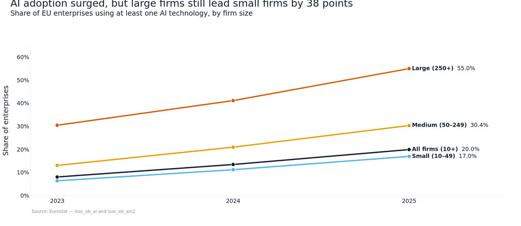

```python
fig_01_eu_acceleration(data).show()
```

## Question 2: Has rapid growth closed the AI adoption divide between EU countries?

**Why it matters.** A rising EU average is not enough if national gaps continue to widen.

**Method.** Compare every EU country's 2023 and 2025 adoption levels on the same scale.

**Finding.** No. By 2025, Denmark reached **42.0%** while Romania remained at **5.2%**, leaving a **36.8-point** spread.

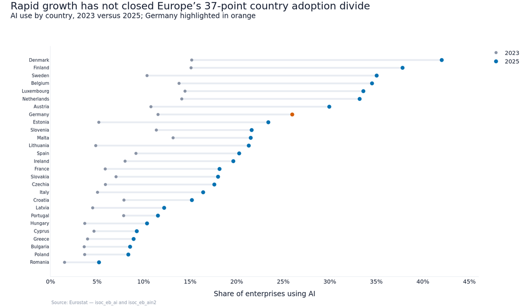

```python
fig_02_country_divergence(data).show()
```

## Question 3: Did 2025 growth favour existing leaders or allow lagging countries to catch up?

**Why it matters.** The relationship between starting level and subsequent growth reveals whether the divide is likely to narrow.

**Method.** Plot each country's 2024 adoption rate against its percentage-point increase from 2024 to 2025.

**Finding.** The pattern is mixed. Denmark and Finland were already leaders and accelerated strongly, while Lithuania was the clearest catch-up case. Denmark added the most: **14.5 points**.

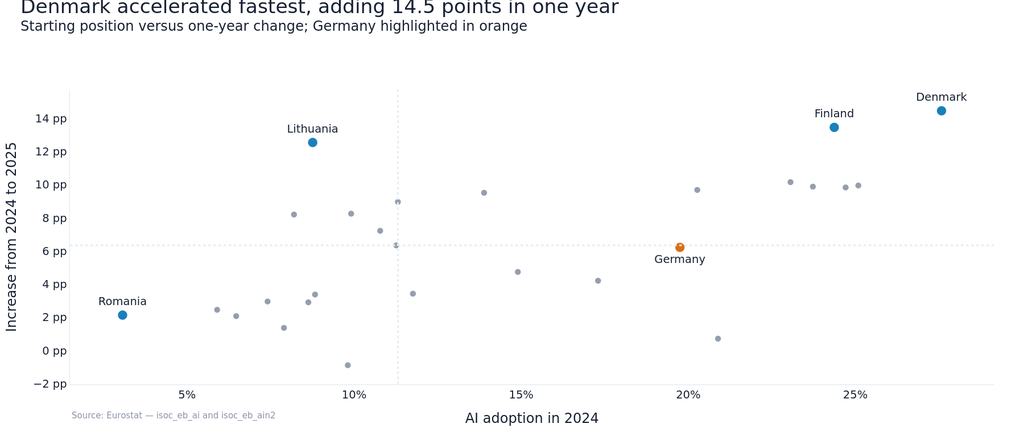

```python
fig_03_country_acceleration(data).show()
```

## Question 4: Where is the gap between small and large firms most severe?

**Why it matters.** A country's overall adoption rate can conceal unequal access to AI capability.

**Method.** Calculate the 2025 percentage-point difference between large and small enterprises for each EU country, then rank the twelve widest gaps.

**Finding.** Slovenia had the widest gap at about **53.5 points**, followed by Belgium and Finland. The size divide is not restricted to low-adoption countries.

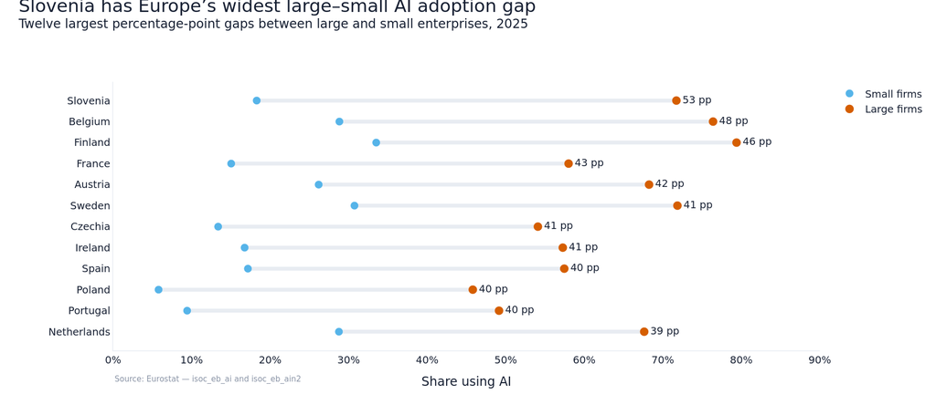

```python
fig_04_size_gap(data).show()
```

## Question 5: Are firms building mature AI portfolios or only experimenting with one tool?

**Why it matters.** Using one AI technology is a weaker signal of organisational maturity than using several complementary technologies.

**Method.** Compare the share of firms using at least one, at least two, and at least three AI technologies by size.

**Finding.** Breadth falls sharply at every size. Only **8.3%** of all EU firms used three or more AI technologies in 2025; the figure was 33.6% for large firms but only 6.5% for small firms.

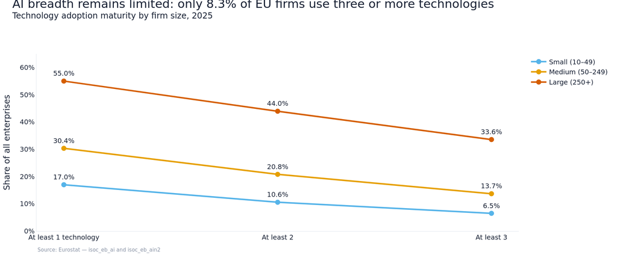

```python
fig_05_maturity(data).show()
```

## Question 6: Does the technology mix differ between small and large AI adopters?

**Why it matters.** Comparing raw technology rates would mostly reproduce the adoption gap, so this question conditions each technology on the AI-adopter base.

**Method.** For each size group, divide technology-specific adoption by overall AI adoption to estimate the technology's share among adopters.

**Finding.** Text mining leads both groups, but large adopters use a broader stack. Machine learning reaches about **45.5% of large adopters** versus **22.4% of small adopters**.

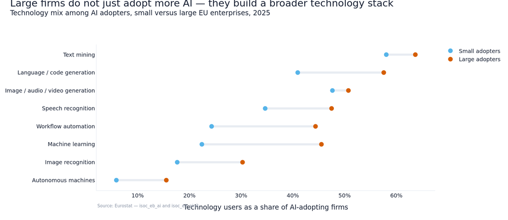

```python
fig_06_technology_mix(data).show()
```

## Question 7: Which economic sectors are pulling ahead, and which remain structurally behind?

**Why it matters.** Sector-specific usefulness and digital maturity may shape adoption more strongly than the EU average suggests.

**Method.** Compare 2023 and 2025 adoption across eleven high-level economic activities.

**Finding.** Information and communication reached **62.5%** in 2025, while construction remained at **10.8%**. Every sector grew, but the leaders increased fastest in absolute terms.

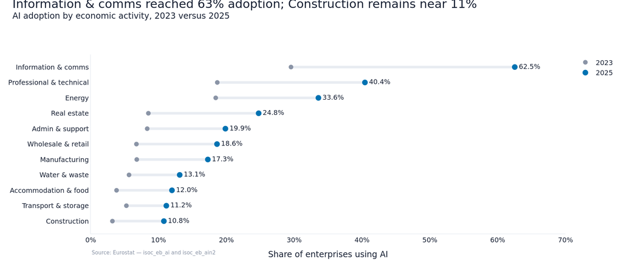

```python
fig_07_sector_growth(data).show()
```

## Question 8: How are the business purposes of AI changing among firms that already adopted it?

**Why it matters.** Adoption volume says little about where firms expect business value.

**Method.** Compare purpose-specific shares among AI adopters in 2024 and 2025.

**Finding.** Marketing and sales remained the most common purpose at **34.7%**. Administration and management gained the most (**+3.5 points**), while production and ICT security declined as shares of the rapidly expanding adopter base.

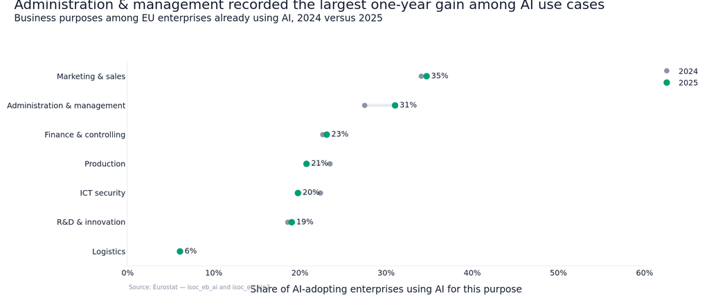

```python
fig_08_purpose_growth(data).show()
```

## Question 9: Do sectors use AI for the same business purposes?

**Why it matters.** A single cross-sector AI strategy would be weak if use cases depend heavily on operating context.

**Method.** Cross-tabulate seven AI purposes with eleven high-level sectors for 2025, using the share among AI adopters.

**Finding.** The purpose mix is clearly sector-specific: information and communication leans toward R&D and generation-related work, while accommodation and food services are heavily oriented toward marketing and sales.

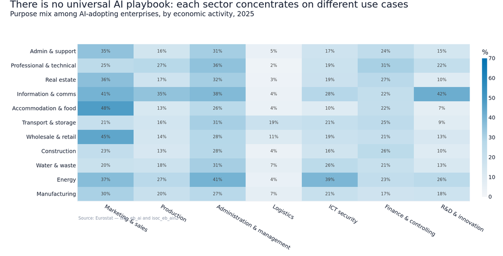

```python
fig_09_sector_purpose_heatmap(data).show()
```

## Question 10: Is latent interest in AI strongest in sectors that already have high adoption?

**Why it matters.** If high-adoption sectors also have the largest pipeline of interested non-users, today's divide may persist.

**Method.** Plot current adoption against the share of non-users that considered AI for each sector.

**Finding.** Interest and adoption move together. Information and communication combines **62.5% adoption** with **32.0% consideration among non-users**; construction is low on both measures.

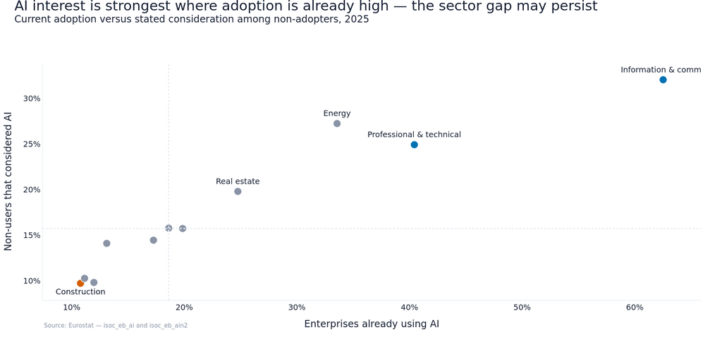

```python
fig_10_interest_vs_adoption(data).show()
```

## Question 11: Which barriers stop interested firms from adopting AI, and do they vary by firm size?

**Why it matters.** Intervention priorities differ if firms are blocked mainly by cost, technology, law, or capability.

**Method.** Compare eight barriers across small, medium, and large enterprises among non-users that had considered AI.

**Finding.** Lack of expertise dominates at roughly **70.3%**, ahead of unclear legal consequences (53.6%) and data-protection concerns (52.7%). Cost ranks below skills, law, privacy, data quality, and system compatibility.

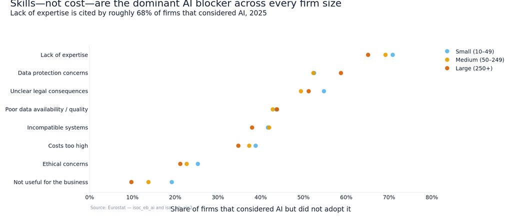

```python
fig_11_barriers(data).show()
```

## Question 12: Does AI adoption occur alongside cloud and data-analytics capabilities?

**Why it matters.** AI deployment may depend on complementary digital foundations rather than a stand-alone tool purchase.

**Method.** Express joint AI-plus-analytics and AI-plus-cloud use as a share of all AI adopters, then compare by firm size.

**Finding.** The relationship is strong. About **92% of large AI adopters** also use data analytics and **94% use cloud services**. The shares are lower for small adopters, especially for analytics (63%).

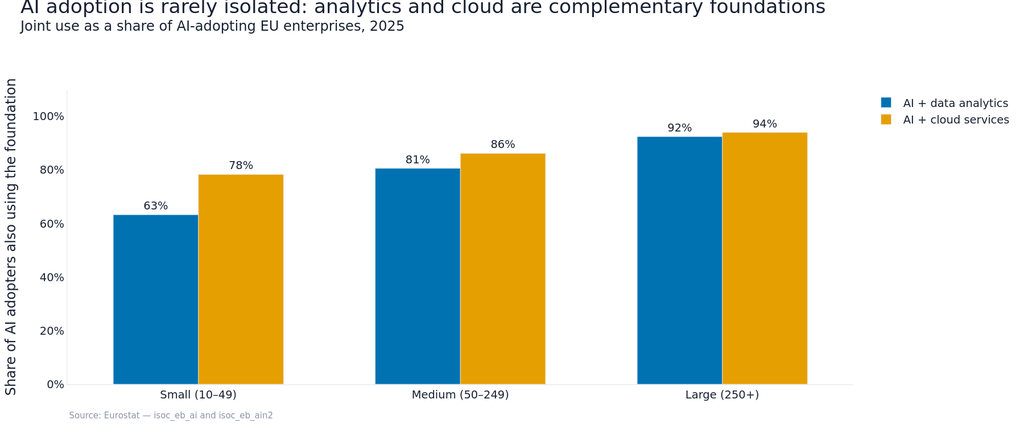

```python
fig_12_digital_foundations(data).show()
```

## Conclusion: acceleration without convergence

The central story is not simply that European businesses are adopting AI. They are adopting it **quickly but unevenly**.

Country, firm size, sector, and existing digital capability divide the market. The leaders are not only more likely to use AI; they are also more likely to use several AI technologies and combine them with analytics and cloud services. Meanwhile, the most common barrier is not that businesses see no value in AI. It is that they lack the expertise to implement it and remain uncertain about legal and data-protection consequences.

This means the adoption gap is unlikely to close through cheaper tools alone. Smaller firms and slower sectors need implementation capability, relevant use cases, trustworthy governance, and access to complementary digital infrastructure.

## Limitations and responsible interpretation

1. **Aggregate data:** These are national and sector percentages, not individual firm records. The analysis cannot explain within-group variation.
2. **No causal claims:** A relationship between firm size and adoption does not prove that size itself causes adoption.
3. **Changing survey context:** AI technologies and survey wording evolve. Eurostat status flags remain in the dataset, and flagged comparisons require caution.
4. **Different denominators:** Purpose and barrier questions are conditional on specific subgroups. They should not be read as shares of all enterprises.
5. **Sector composition:** Country differences may partly reflect industrial structure, digital infrastructure, skills, and policy context not directly measured here.

## Reproducibility

- Run `python -m src.data_pipeline` to refresh the curated CSV from Eurostat.
- Run this notebook from the repository root.
- Run `streamlit run app.py` to launch the interactive dashboard.
- All charts use Plotly only and share the same color-vision-deficiency-safe visual system.